# ANLYTC3 Homework 4

Julian Terry S. Bass

#### Instructions

The due date is 09:30AM on Feb 23 (Tue). Submit BOTH the Knit HTML file and the Rmd file.

Code should be clearly commented. Plots should be presentable and properly labeled. Mitigate overplotting whenever possible.

#### Preliminaries

We’ll use the data file `dataset_hw4.csv`, which should be in the same directory as this markdown file (which should also be your working directory). It is a data frame of expenditures by household from the consumer expenditure survey

#### Questions

**Problem 1:**

Group the households into two categories:

- apartments: those whose `home.type` is “apartment or flat” or “high-rise”
- homes: those whose `home.type` is “single family detached”

Compare the `housing` expenditures for the two groups using a quantile plot. Do they appear different?

```r
library(plyr)
library(ggplot2)
library(reshape2)
expenditures = read.csv(file = 'dataset_hw4.csv', header = TRUE)
```

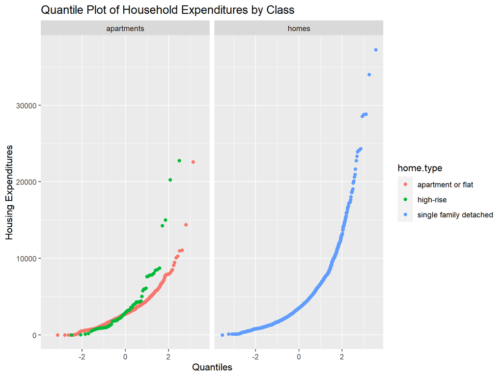

```r
# fill in

# Subset for home categories
apartments.and.homes = subset(expenditures, home.type == "apartment or flat" | home.type == "high-rise" | home.type == "single family detached")

# if else statement classified single family detached homes into "homes" category
# Other types of homes (apartments, high-rises and flats) get put into "apartments" category
apartments.and.homes$categories = ifelse(apartments.and.homes$home.type == "single family detached", "homes", "apartments")

# Method 1: Plotting housing expenditures data by categories mentioned above, and colored by home type
qplot(sample = housing, data = apartments.and.homes, color=home.type) + facet_wrap(~ categories) +
  labs(x = "Quantiles", y = "Housing Expenditures", title = "Quantile Plot of Household Expenditures by Class")
```

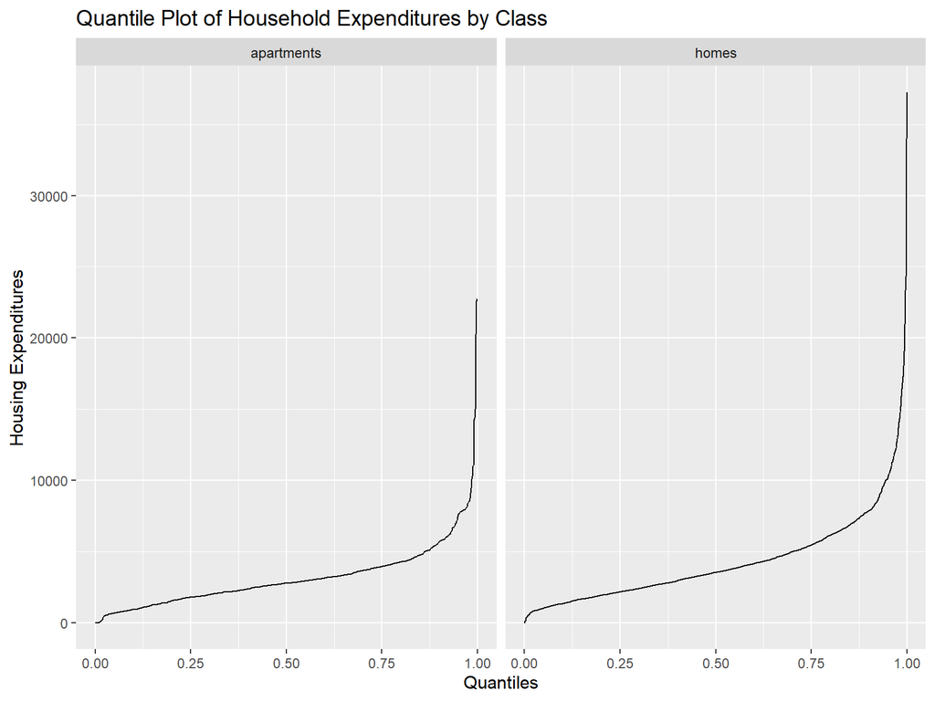

```r
# Method 2: Plotting with ggplot and stat_qq
ggplot(apartments.and.homes, mapping = aes(sample = housing)) +
  stat_qq(geom = "line", distribution = "qunif", size = 0.5) +
  facet_wrap(~ categories) +
  labs(x = "Quantiles", y = "Housing Expenditures", title = "Quantile Plot of Household Expenditures by Class")
```

ANS: It seems that according to method 1, single, detached families have noticeably higher housing expenditures compared to apartments, flats and high-rises. Detached families also appear to be more consistent along the curve showing a more defined linear relationship whereas apartments, flats and high-rises are more concentrated on lower expenditures with a few higher outliers.

Method two doesn’t identify the outliers as well, but that’s more on the visualization technique. We can see that homes and appartments follow a similar curve with homes reaching higher expenditures.

**Problem 2:**

Compare the `housing` expenditures but first take a log transform. (Exclude those who spent zero or negative amounts on `housing` from the analysis)

Use quantile plots and/or QQ plots to compare the two groups after the log transform. If helpful, also compare the residuals. What are the similarities and differences between the two groups?

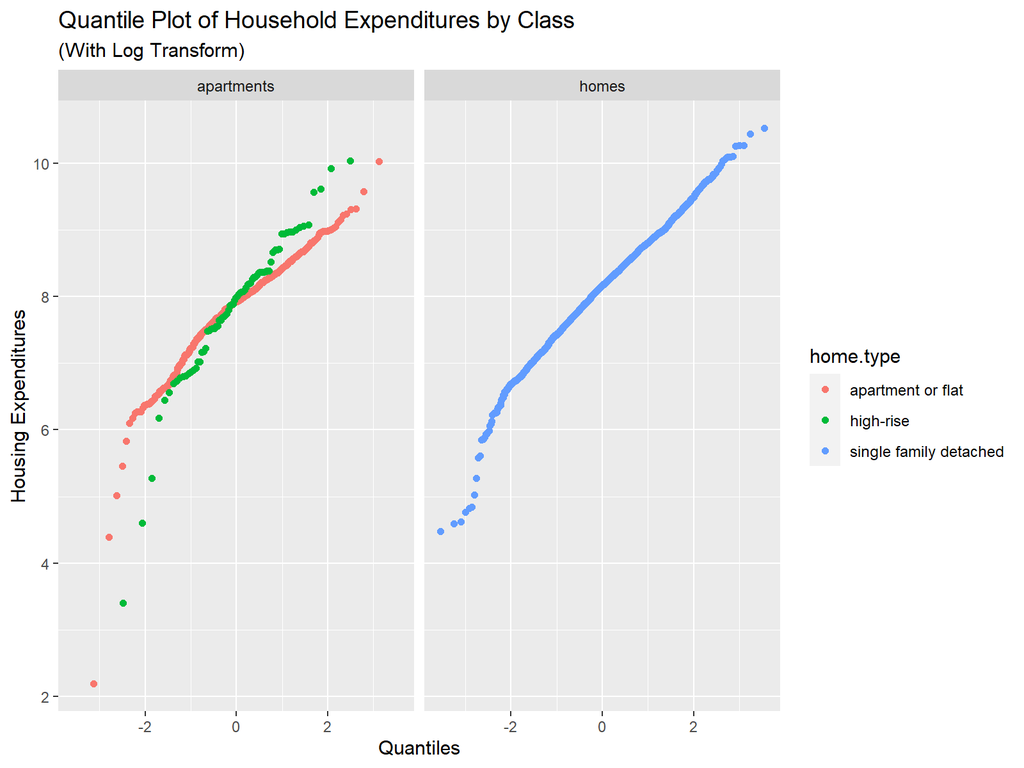

```r
# fill in

# log transform for housing expenditures column being stored in "log.housing"
apartments.and.homes$log.housing = log(apartments.and.homes$housing)

# subset to remove zero or negative housing expenditure values
apartments.and.homes = subset(apartments.and.homes, subset = !is.na(housing) & housing > 0)

# Method 1: plotting with log housing expenditures data, grouping by category and coloring by home type
qplot(sample = log.housing, data = apartments.and.homes, color=home.type) + facet_wrap(~ categories) +
  labs(x="Quantiles", y="Housing Expenditures", title = "Quantile Plot of Household Expenditures by Class", subtitle = "(With Log Transform)")
```

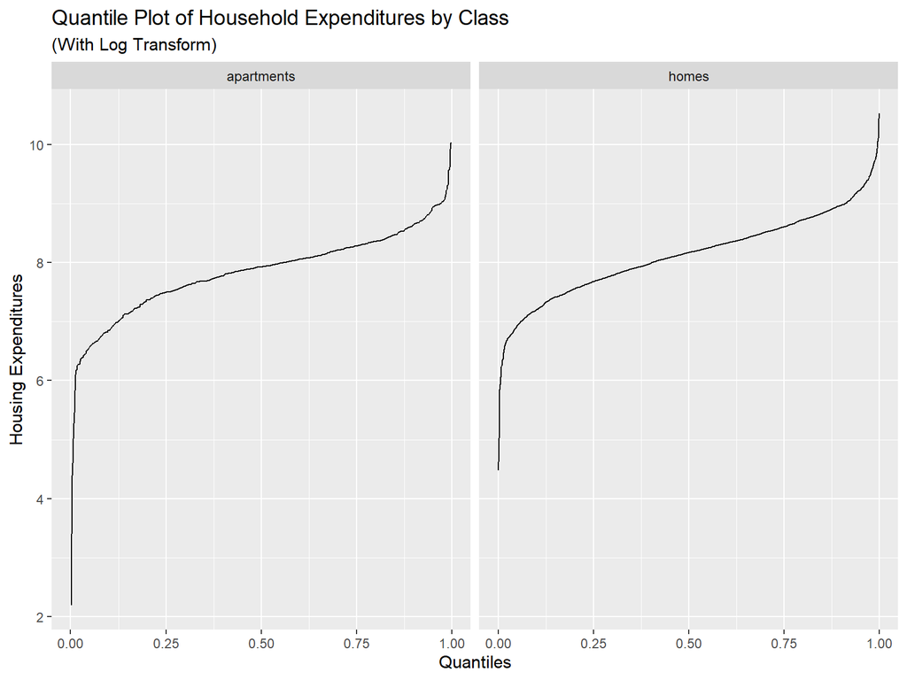

```r
# Method 2: Plotting with ggplot and stat_qq
ggplot(apartments.and.homes, mapping = aes(sample = log.housing)) + stat_qq(geom="line", distribution="qunif", size = 0.5) + facet_wrap(~ categories) + labs(x="Quantiles", y="Housing Expenditures", title = "Quantile Plot of Household Expenditures by Class", subtitle = "(With Log Transform)")
```

ANS: According to method 1, they both seem to have the same average housing expenditures according to this visualization wherein their midpoints fall around the 8 mark. It bears a similarity with the visualization from Problem 1 wherein apartments, flats and high-rises have more dispersed data with outliers while detached homes show more linear consistency.

Method 2 shows similar results when it comes to point concentration and the “midpoint” between both home types.

** Problem 3:**

Using the `movies` data set that comes with `ggplot2`, visualize the distribution of ratings for movies before and after 1930.

How do the distributions differ? Should the distributions be compared with or without a log transform?

You may want to adjust the size of the points to reduce overplotting.

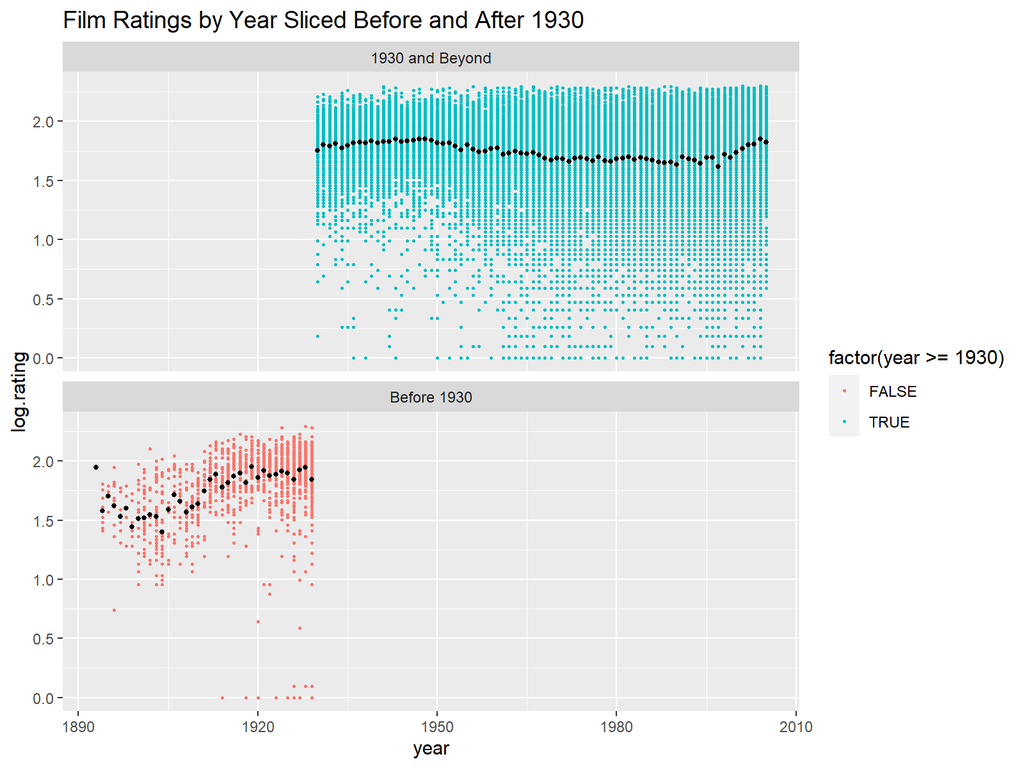

```r
# fill in
library(ggplot2movies)

# if else statement to create two year categories splitting before and after 1930
movies$year.groupings = ifelse(movies$year >= 1930, "1930 and Beyond", "Before 1930")

# log transform for movie rating column
movies$log.rating = log(movies$rating)

# plotting log rating data according to year and grouping by year categories
# geom_line is added to color years according to 1930 split
# stat_summary adds average ratings point in black for each year
ggplot(movies, aes(x = year, y = log.rating)) +
    geom_point(aes(color = factor(year >= 1930)), size = 0.5) +
    stat_summary(fun.data = mean_cl_boot, geom = "point", color = "black", size = 1) +
    facet_wrap(~ year.groupings, nrow = 2) +
  labs(title = "Film Ratings by Year Sliced Before and After 1930")
```

ANS: In this case, log transform made a huge difference in the visualization especially when it came to my use of geom_point(). With the original data, the point distributions for ratings per year were far too varied and made it difficult to see the true variation among ratings per year.

The variations are still rather strong for years beyond 1930, but are much more manageable.

** Problem 4:**

Compare the distribution of ratings for each of the genres: action, animation, comedy, drama, documentary, romance, and short. If a movie belongs to more than one genre, include it in both distributions. Use both quantile plots and Q-Q plots.

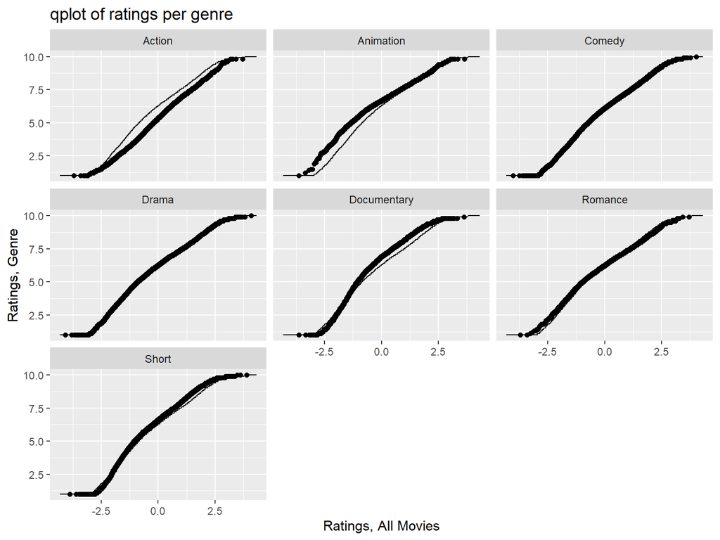

```r
# fill in

# ----------Received Help from Zinedine and Andre----------

# ----------qplot output----------

# creating the subset for movies genres along with the year and rating.
ratings = subset(movies, select = c('year', 'rating', names(movies)[18:24]))

# Melting all genres in a single column
ratings = melt(ratings, measure.vars = names(movies)[18:24])

# Creating a subset for ratings with value = 1.
ratings = subset(ratings, value == 1)

# setting a data frame for rating column only.
ratings.only = ratings["rating"]

# plotting my subset using qplot.
ggplot(data = ratings, mapping=aes(sample=rating)) + stat_qq(dist='qunif') + facet_wrap(~ variable) + stat_qq(data=ratings.only, mapping=aes(sample=rating), dist='qunif', geom='line') + labs(title = "qplot of ratings per genre", x='Ratings, All Movies', y='Ratings, Genre')
```

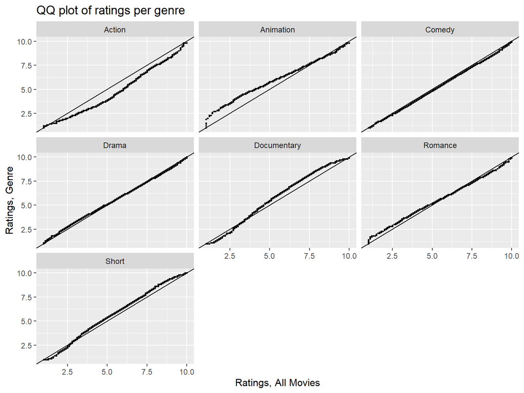

```r
# ----------QQ plot output----------

# creating the qqplot function.
QQ.pooled = function(data, y) {
  n.pts = min( length(data$rating), length(y))
  probs = seq(from = 0, to = 1, length.out = n.pts)
  q1 = quantile(data$rating, probs= probs)
  q2 = quantile(y, probs=probs )
  return( data.frame(q1 = q1, q2 = q2, quantile = probs) )
}
# the plotting of qqplot.
QQ.plot = ddply(ratings, "variable", QQ.pooled, y=ratings.only$rating)
ggplot(data = QQ.plot, mapping=aes(y = q1, x=q2)) + facet_wrap('variable') + geom_point(size=.5) + geom_abline() + labs(title = "QQ plot of ratings per genre", x='Ratings, All Movies', y='Ratings, Genre')
```

Also, which worked better for answering the T/F questions: quantile plots or QQ plots?

ANS: The Q-Q plot in this case looked a lot cleaner and made it easier to visualize the distributions across different quantiles.

** Problem 5:**

Compare the distribution of ratings for each of the genres, and also for the following time periods: 1900-1920, 1921-1940, 1941-1960, 1961-1980, 1981-2000 (i.e., there should be 35 groups total). Use both quantile plots and Q-Q plots.

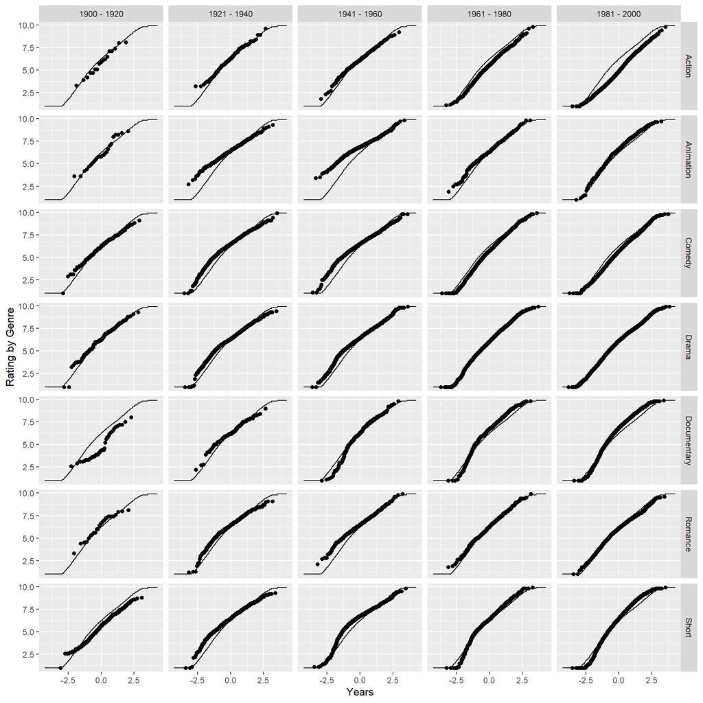

```r
# fill in

# ----------Received Help from Zinedine and Andre----------

# Creating a subset 1900 - 2000
time.period.sub = subset(movies, year >= 1900 & year <= 2000)

# Creating time.period column with cut year segments
time.period.sub$time.period = with(time.period.sub, cut(x = year, breaks = c(1900, 1921, 1941, 1961, 1981, 2001), labels = c("1900 - 1920", "1921 - 1940", "1941 - 1960" , "1961 - 1980", "1981 - 2000"), right = FALSE))

# Meltiing the genres into a sing column
time.period.melt = melt(time.period.sub, id.vars = c("time.period", "rating"), measure.vars = c("Action", "Animation", "Comedy", "Drama", "Documentary", "Romance", "Short"))

# Creating a subset for ratings with value = 1.
time.period.melt = subset(time.period.melt, value == 1)

# Creating a data frame for the raiting only.
time.period.melt.rating = time.period.melt["rating"]

# ----------qplot output----------

ggplot(data = time.period.melt, mapping = aes(sample = rating)) + stat_qq() + facet_grid(variable ~ time.period) + stat_qq(data = time.period.melt.rating, mapping = aes(sample = rating), geom = "line") + labs(y = "Rating by Genre", x = "Years" )
```

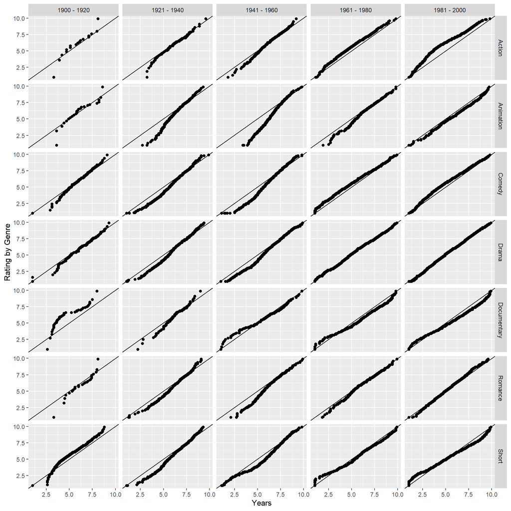

```r
# ----------QQ plot output----------

qq.values.time.period = ddply(time.period.melt, c("variable", "time.period"), QQ.pooled, y = time.period.melt.rating$rating)

ggplot(data = qq.values.time.period, mapping = aes(x=q1, y=q2)) + geom_point() + geom_abline() + facet_grid(variable ~ time.period) + labs(y = "Rating by Genre", x = "Years" )
```

- Describe how the distribution of ratings for action movies changed over time, relative to the pooled ratings
- Describe how the distribution of ratings for comedies changed over time, relative to the pooled ratings